# Assignment 3: Sentiment Classification Reflection

## Training Dynamics

### MLP Training

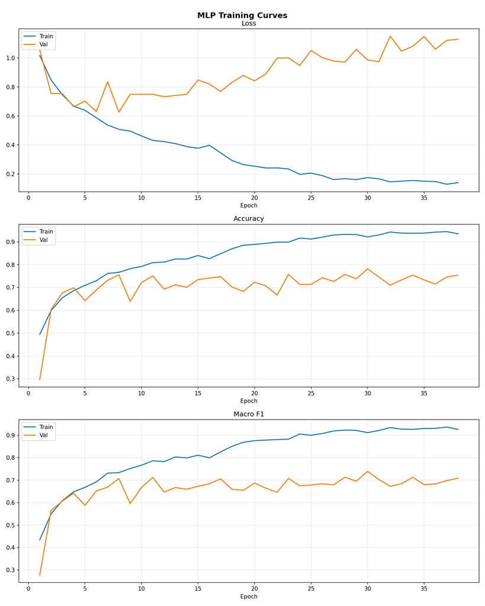

mlp_training_curves.png

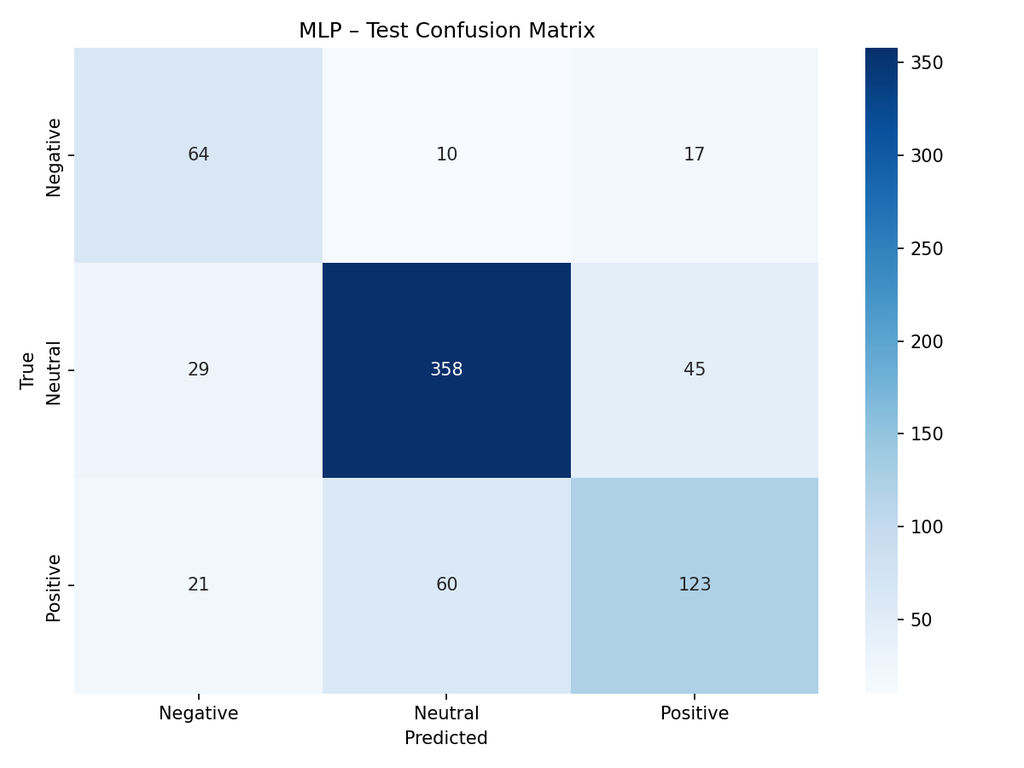

mlp_confusion_matrix.png

### LSTM Training

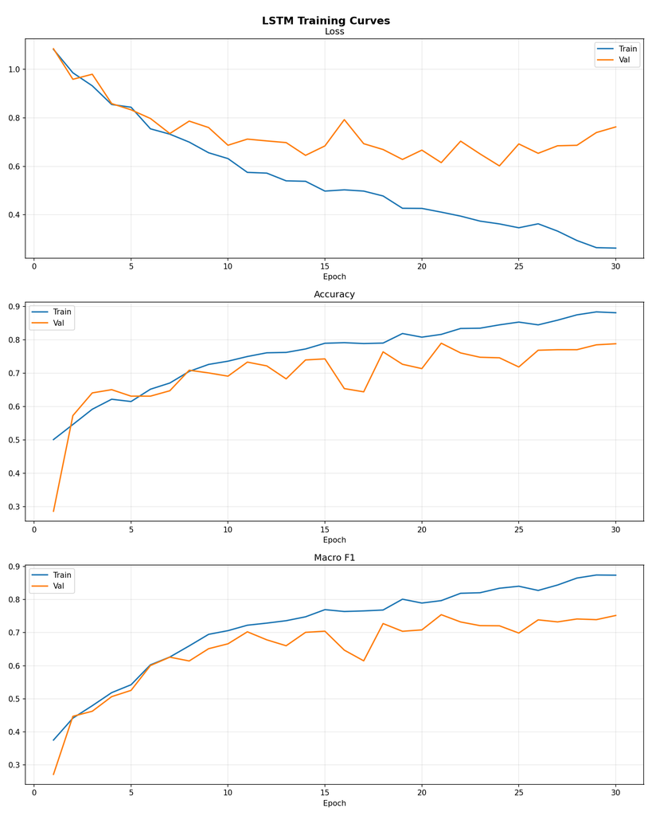

lstm_training_curves.png

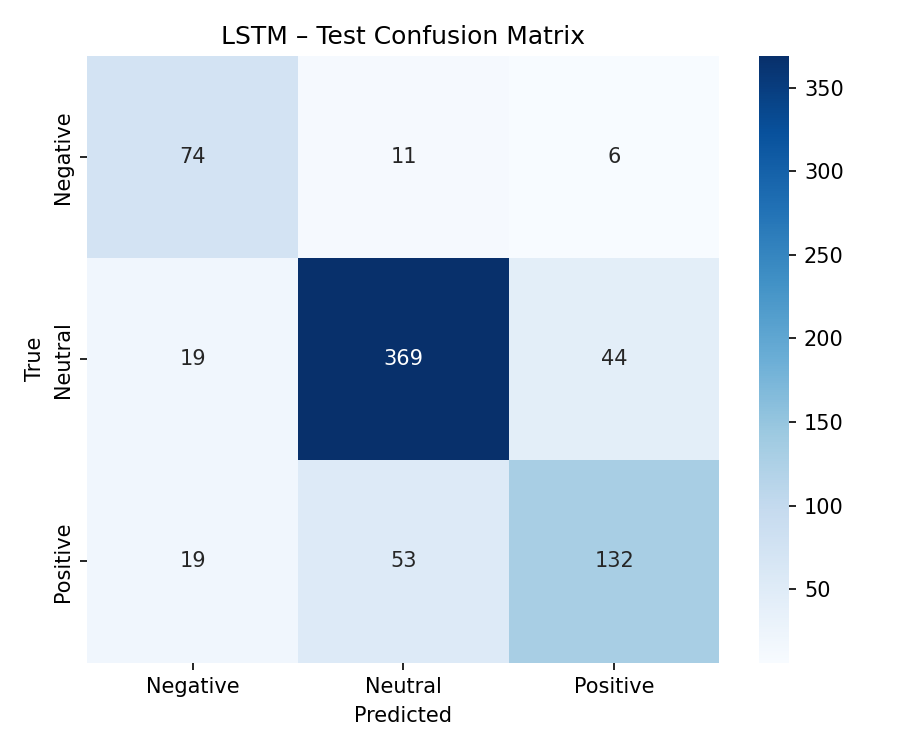

lstm_confusion_matrix.png

Both the MLP and LSTM models exhibited clear signs of overfitting, although the severity and timing differed between the two. In the MLP, the training loss decreased steadily while training accuracy and macro F1 continued to rise, but the validation loss began increasing after a few epochs and validation performance plateaued. This growing gap between training and validation loss indicates that the MLP quickly memorized the training data without learning features that generalized well to unseen examples. In contrast, the LSTM also overfit but did so more gradually. Its validation loss improved for a longer period, and the gap between training and validation curves are noticeably smaller, indicated that LSTM inherently was able to extract more generalizable patterns before overfitting became dominant. Architectural or training changes such as stronger regularization, reducing the minimum epochs, or reducing hidden layers in the model could help mitigate overfitting in both models.

The use of class weights has a impact on both training stability and final performance by reducing the dominance of the Neutral class during optimization. This encourages the models to attend more carefully to underrepresented Positive and Negative examples. While this led to slightly noisier training curves due to less uniform gradient updates, the overall effect was beneficial. Macro F1 improved, and the resulting confusion matrices showed more balanced predictions across sentiment classes. This tradeoff allows for better generalization and fairness across classes.

## Model Performance and Error Analysis

Between the two models, the LSTM generalized better to the test set than the MLP. This is shown by a slightly higher test macro F1 score and a smaller discrepancy between training and validation metrics. The LSTM’s confusion matrix shows fewer extreme off-diagonal errors and more consistent performance across classes (only performing worse in the neutral-predicted, true-negative category by 1). These results indicate that the LSTM’s ability to process sequences and maintain contextual information allowed it to better capture the structure of sentiment-bearing language.

When weighted by class frequency, positive sentiment was the most frequently misclassified class. Positive sentiment (especially in financial texts) can be fairly similar to neutral sentiment as words such as “productive” or “better than expected” can be interpreted ambiguously depending on context, unlike negative language, which tends to be more explicit. With the lack of clear “positive” words, the model might be more willing to default to a neutral interpretation. Additionally, specific phrases like “not bad” or “could have been worse” can carry positive meaning, but sentiment emerges from the interaction between words rather than from individual tokens which may make it difficult for the model to interpret.

## Cross-Model Comparison

### RNN

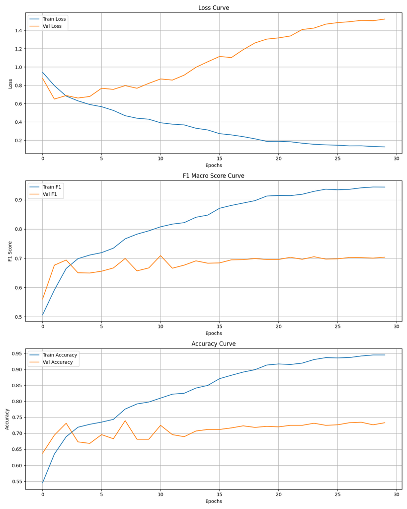

rnn_f1_learning_curves.png

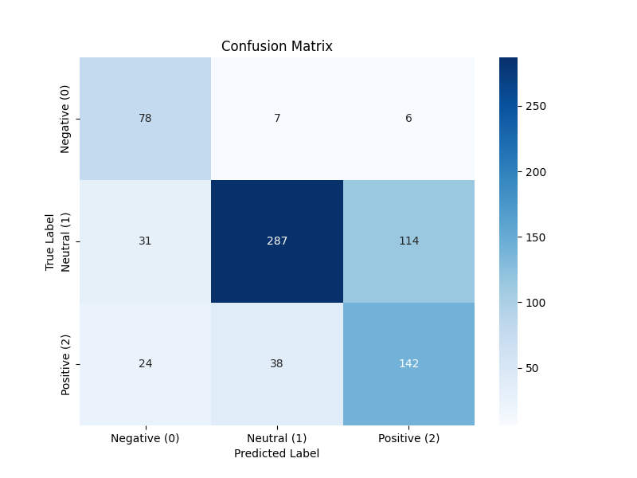

rnn_confusion_matrix.png

### MLP

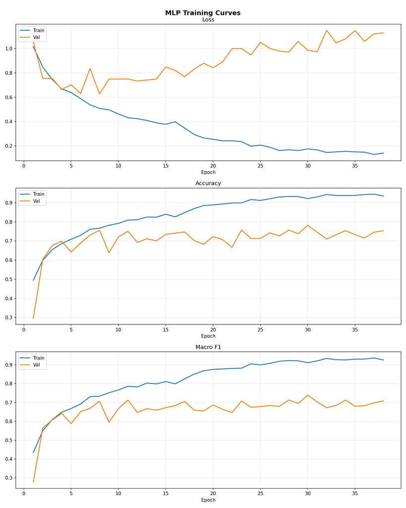

mlp_training_curves.png

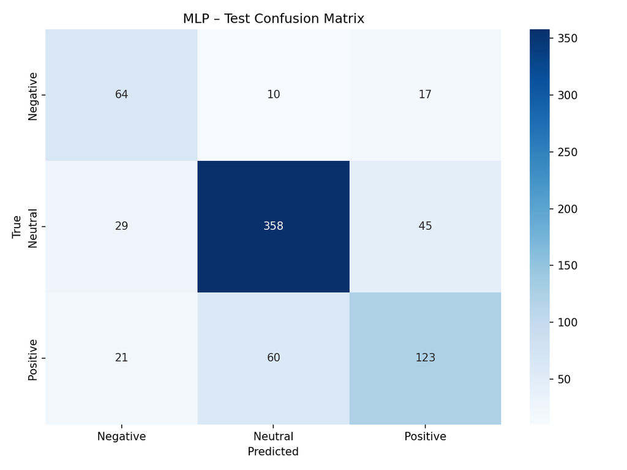

mlp_confusion_matrix.png

### GRU

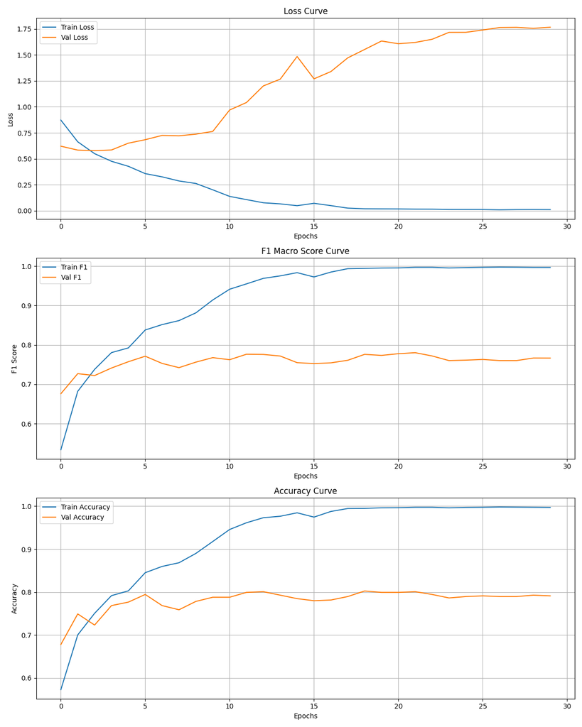

gru_f1_learning_curves.png

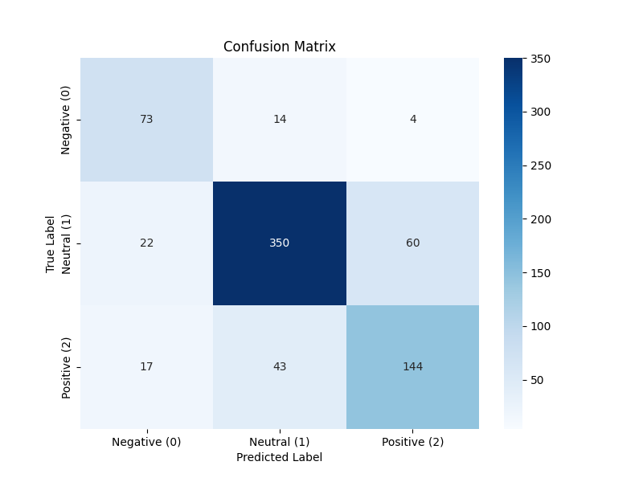

gru_confusion_matrix.png

### LSTM

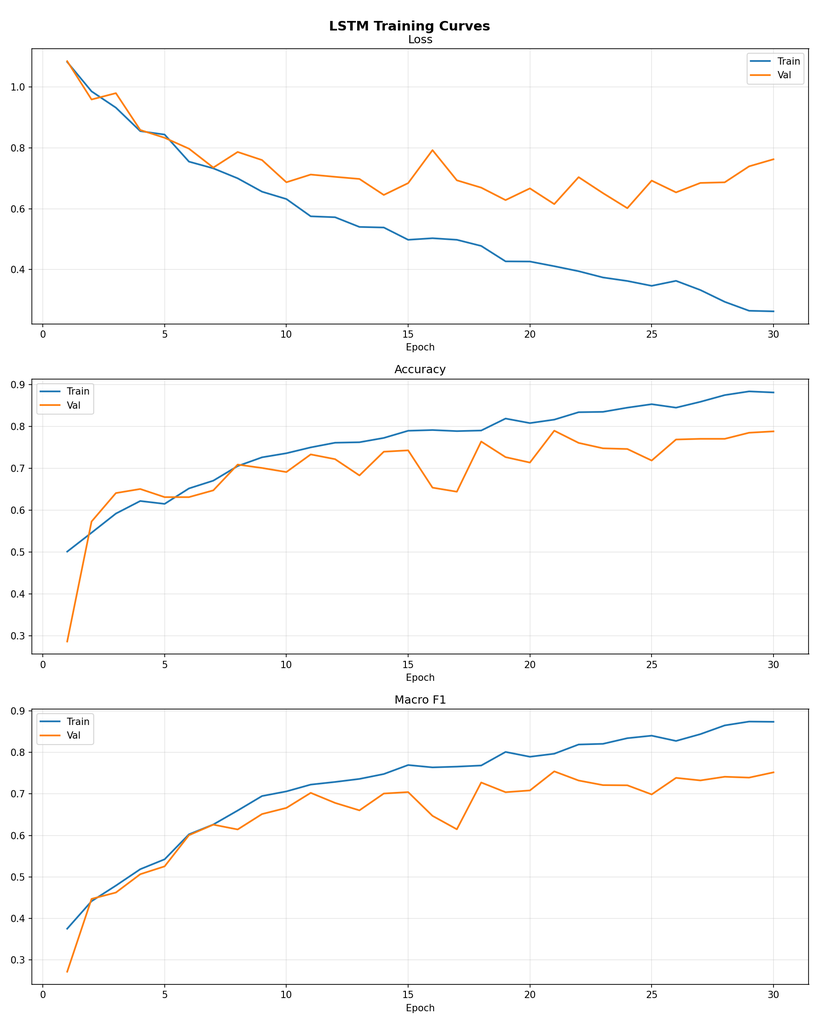

lstm_training_curves.png

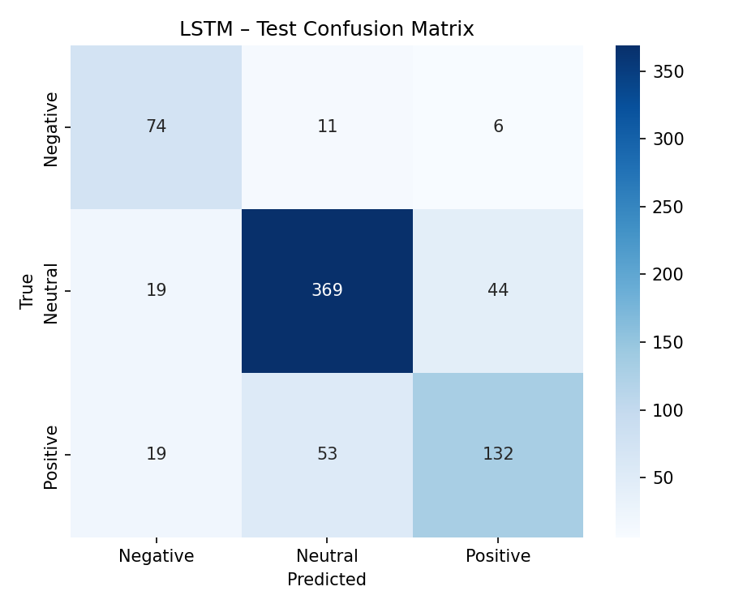

lstm_confusion_matrix.png

### BERT

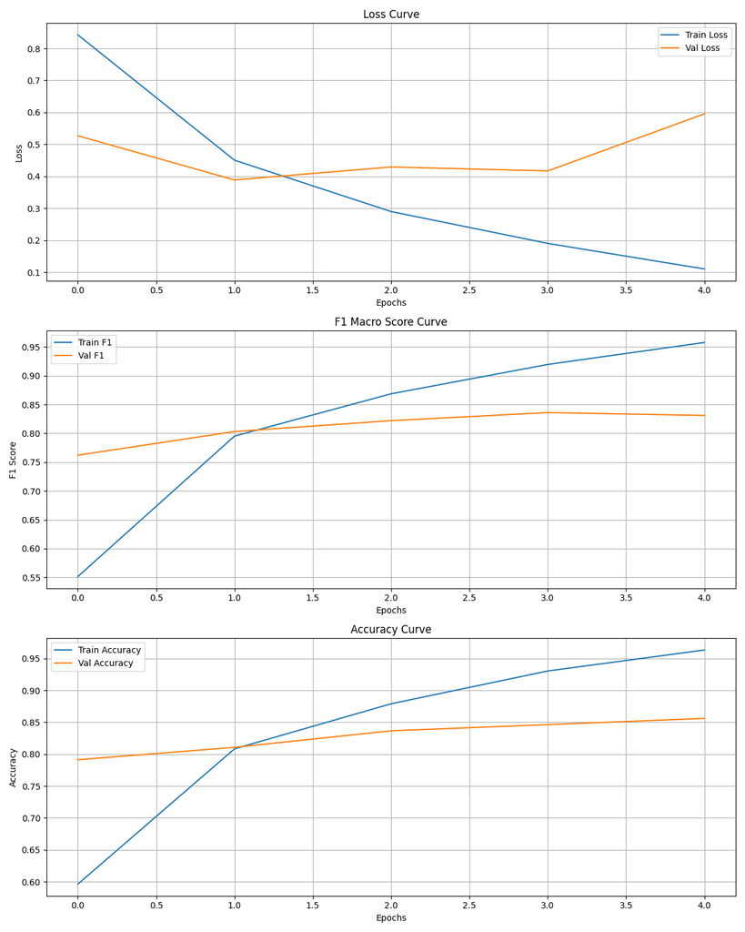

bert_f1_learning_curves.png

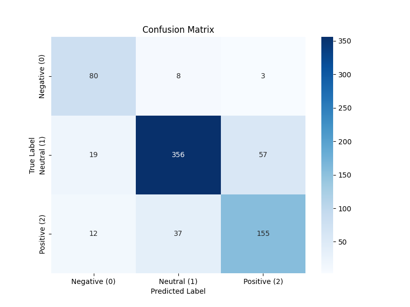

bert_confusion_matrix.png

### GPT

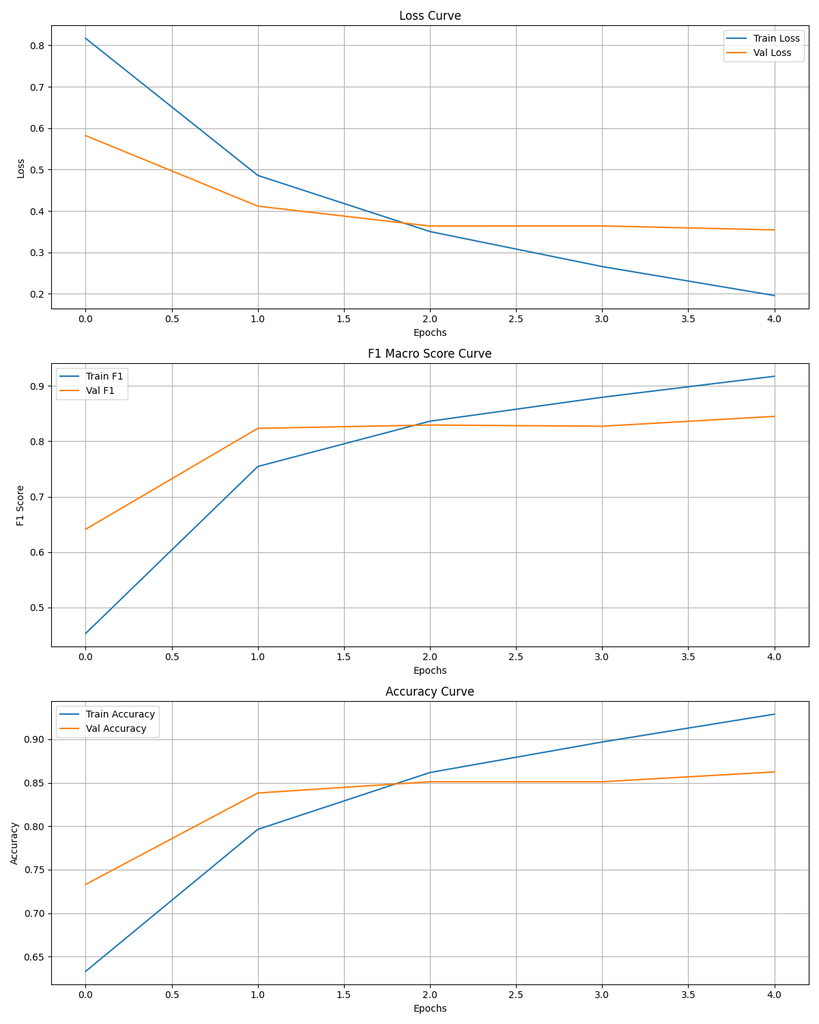

gpt_f1_learning_curves.png

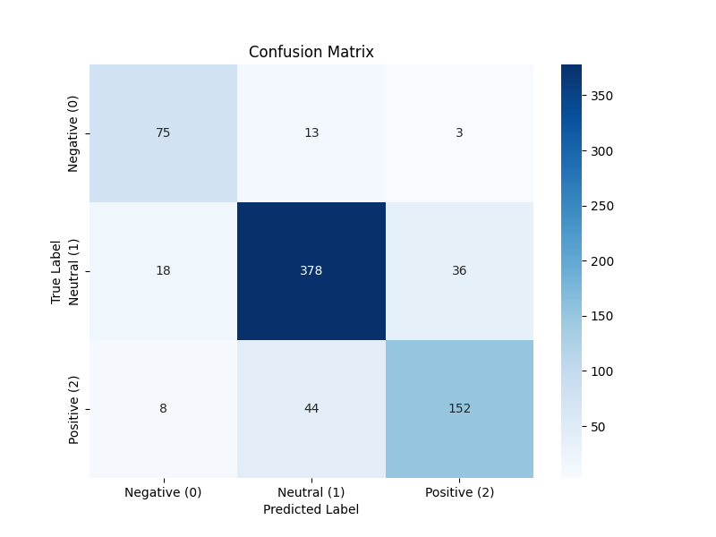

gpt_confusion_matrix.png

### Responses

The MLP is fundamentally limited by its reliance on mean-pooled FastText embeddings. Mean pooling reduces an entire sentence to a single averaged vector, which means the model effectively sees the sentence as a “bag of words” rather than a structured sequence. Information about word order and how words interact is lost in this process. As a result, the MLP struggles with sentiment that depends on context. This loss of structure makes it harder for the MLP to distinguish subtle sentiment differences, leading to weaker generalization and higher misclassification rates.

The LSTM addresses these limitations by processing text sequentially rather than all at once. Instead of averaging words, the LSTM reads the sentence word by word and maintains a memory of what it has seen so far. This allows it to track how sentiment develops across the sentence and to understand how earlier words influence the meaning of later ones. Because of this, the LSTM can better capture phrases where sentiment depends on word order or context, which helps explain its stronger validation and test performance.

Fine-tuned large language models such as BERT and GPT outperform both the MLP and classical sequence models because they start with a much higher understanding of language. These models are pretrained on massive and diverse text corpora, allowing them to learn nuanced patterns and context. When fine-tuned, they can apply this prior knowledge to recognize subtle sentiment cues, handle long-range dependencies, and figure out ambiguous phrasing far more effectively than models trained from scratch or with static embeddings.

From my test results, the models ranked in performance as GPT, BERT, LSTM, GRU, MLP, and RNN. Though, this ranking may vary slightly across runs due to randomness in initialization and training. Both GPT and BERT performed well due to being transformer-based models (having a unidirectional and bidirectional attention mechanism respectively), and their test performances are similar. As for the classical baselines, the MLP model should’ve performed the worst as it does not model sequences at all, but RNN suffers from vanishing or exploding gradients which can lead to less stable predictions resulting in a lower test score (even if RNN explicity models sequential order). GRU improves upon the RNN and MLP by introducing gating mechanisms that control how information flows through time. These gates allow the model to retain relevant information longer and forget irrelevant signals. LSTM performs better than the three other classical models as further it extends upon the idea of GRU with a more expressive memory cell and separate input, forget, and output gates. This allows it to model longer-range dependencies and more complex patterns.

## AI Use Disclosure (Required)

If you used any AI-enabled tools (e.g., ChatGPT, GitHub Copilot, Claude, or other LLM assistants) while working on this assignment, you must disclose that use here. The goal is transparency-not punishment.

In your disclosure, briefly include: - **Tool(s) used:** (name + version if known) - **How you used them:** (e.g., concept explanation, debugging, drafting code, rewriting text) - **What you verified yourself:** (e.g., reran the notebook, checked outputs/plots, checked shapes, read documentation) - **What you did *not* use AI for (if applicable):** (optional)

You are responsible for the correctness of your submission, even if AI suggested code or explanations.

#### Write your disclosure here.

Claude Sonnet 4.5 and ChatGPT 5.2

- Claude was used to draft code for the LSTM and MLP models.
- ChatGPT was used to explain concepts about each model, help with explaining various parameters and optimization, and also some debugging.

I vertified conceptual ideas from class notes and websites found online.